# Quiz 250505 (Prospect Theory)

coop711

2025-05-05

# 10주차 데이터 실험 집계

## 실험의 목적

10주차 구글 예습 설문지 집계결과를 분석합니다.

Q1 ~ Q6에서는 랜덤화의 효과로 Red, Black 이 얼마나 닮았는지 알아봅니다.

Q7에서는 Prospect Theory 에서 이득은 확고히 하고 손실은 회피하려는 심리에 대해서 살펴봅니다.

제출시간의 분포가 날마다 고른지, Red, Black 간에는 닮았는지 알아봅니다.

### Red, Black을 잘못 표시한 사람들

|  | Red(구글예습퀴즈) | Black(구글예습퀴즈) |
| --- | --- | --- |
| **Red(랜덤화출석부)** | 280 | 2 |
| **Black(랜덤화출석부)** | 1 | 278 |
| **계** | 281 | 280 |

### 응답인원의 Red, Black

Red 로 응답한 인원은 281명, Black 에 응답한 인원은 280명입니다.

전체 응답인원 561 명을 랜덤하게 둘로 나눌 때 어느 한 쪽의 기대인원은 전체 응답인원의 절반인 280.5명이고, 표준오차는 전체 응답인원의 제곱근에 1/2을 곱해 준 11.8 명입니다.

따라서 Red, Black 각 그룹에 관찰된 인원은 기대인원으로부터 표준오차 범위 안에 들어갑니다. 랜덤화출석부에 있는 Red, Black 과 실제 구글설문에 올린 Red, Black 이 다른 사람들의 수효는 3명입니다. Red를 Black 이라고 한 사람이 2명, Black 을 Red 라고 한 사람이 1명입니다.

## Q1. Wilkinson

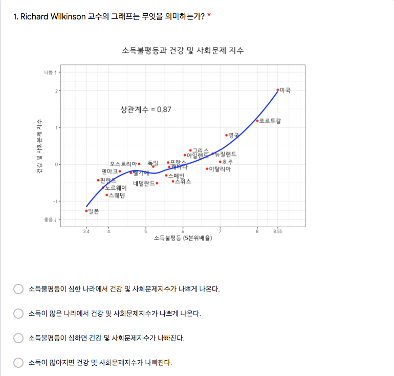

### 소득불평등과 건강 및 사회문제 지표

|  | 소득불평등이 심한 나라에서 건강 및 사회문제지수가 나쁘게 나온다. | 소득이 많은 나라에서 건강 및 사회문제지수가 나쁘게 나온다. | 소득불평등이 심하면 건강 및 사회문제지수가 나빠진다. | 소득이 많아지면 건강 및 사회문제지수가 나빠진다. | 계 |
| --- | --- | --- | --- | --- | --- |
| **Red** | 162 | 37 | 75 | 7 | 281 |
| **Black** | 180 | 29 | 62 | 9 | 280 |
| **계** | 342 | 66 | 137 | 16 | 561 |

Pearson’s Chi-squared test: `.`

[output not shown]

Q1의 집계 결과가 Red, Black 간에 통계적으로 유의한 차이가 있는지 알아보기 위하여 카이제곱 테스트를 수행하였습니다.

실제로 닮은 게 느껴집니까?

### 소득불평등과 건강 및 사회문제 지표 (%)

| 소득불평등이 심한 나라에서 건강 및 사회문제지수가 나쁘게 나온다. | 소득이 많은 나라에서 건강 및 사회문제지수가 나쁘게 나온다. | 소득불평등이 심하면 건강 및 사회문제지수가 나빠진다. | 소득이 많아지면 건강 및 사회문제지수가 나빠진다. | 계 |
| --- | --- | --- | --- | --- |
| 61.0 | 11.8 | 24.4 | 2.9 | 100.0 |

정답률은 Red, Black 을 합하여 계산하는데, 61.0(%) 입니다.

## Q2. 소득 상위1%의 몫과 시대적 사건들

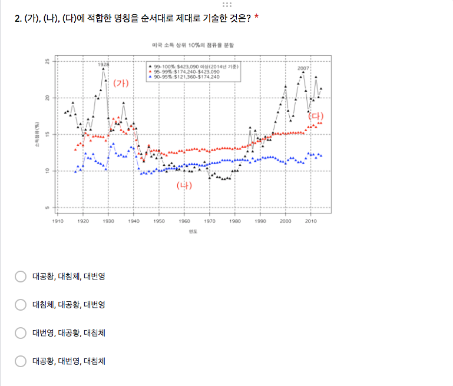

### 대공황. 대번영, 대침체

|  | 대공황, 대침체, 대번영 | 대침체, 대공황, 대번영 | 대번영, 대공황, 대침체 | 대공황, 대번영, 대침체 | 계 |
| --- | --- | --- | --- | --- | --- |
| **Red** | 44 | 40 | 34 | 163 | 281 |
| **Black** | 58 | 23 | 37 | 162 | 280 |
| **계** | 102 | 63 | 71 | 325 | 561 |

Pearson’s Chi-squared test: `.`

| Test statistic | df | P value |
| --- | --- | --- |
| 6.637 | 3 | 0.08442 |

Q2의 집계 결과가 Red, Black 간에 통계적으로 유의한 차이가 있는지 알아보기 위하여 카이제곱 테스트를 수행하였습니다.

그 결과 카이제곱 통계량은 6.637, 자유도는 3, p-value 는 0.0844이므로 Red, Black 간에 통계적으로 유의한 차이를 보이지 않습니다.

실제로 닮은 게 느껴집니까?

### 대공황. 대번영, 대침체(%)

| 대공황, 대침체, 대번영 | 대침체, 대공황, 대번영 | 대번영, 대공황, 대침체 | 대공황, 대번영, 대침체 | 계 |
| --- | --- | --- | --- | --- |
| 18.2 | 11.2 | 12.7 | 57.9 | 100.0 |

정답률은 Red, Black 을 합하여 계산하는데, 57.9(%) 입니다.

## Q3. Piketty의 21세기 자본

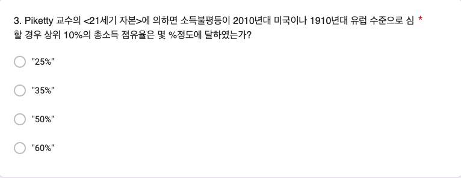

### 상위10%의 총소득 점유율

|  | 25% | 35% | 50% | 60% | 계 |
| --- | --- | --- | --- | --- | --- |
| **Red** | 28 | 63 | 131 | 59 | 281 |
| **Black** | 35 | 66 | 127 | 52 | 280 |
| **계** | 63 | 129 | 258 | 111 | 561 |

Pearson’s Chi-squared test: `.`

| Test statistic | df | P value |
| --- | --- | --- |
| 1.349 | 3 | 0.7175 |

Q3의 집계 결과가 Red, Black 간에 통계적으로 유의한 차이가 있는지 알아보기 위하여 카이제곱 테스트를 수행하였습니다.

그 결과 카이제곱 통계량은 1.349, 자유도는 3, p-value 는 0.7175이므로 Red, Black 간에 통계적으로 유의한 차이를 보이지 않습니다.

실제로 닮은 게 느껴집니까?

### 상위10%의 총소득 점유율 (%)

| 25% | 35% | 50% | 60% | 계 |
| --- | --- | --- | --- | --- |
| 11.2 | 23.0 | 46.0 | 19.8 | 100.0 |

정답률은 Red, Black 을 합하여 계산하는데, 46.0(%) 입니다.

## Q4. World Top Income Database

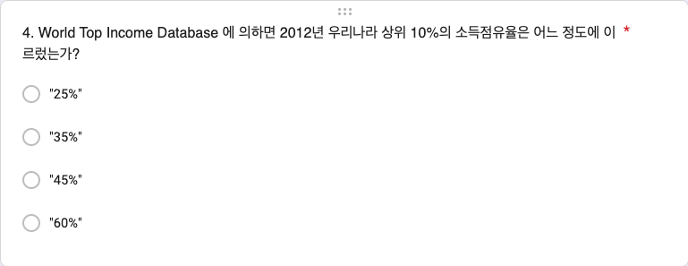

### 우리나라 상위10%의 소득점유율

|  | 25% | 35% | 45% | 60% | 계 |
| --- | --- | --- | --- | --- | --- |
| **Red** | 26 | 46 | 181 | 28 | 281 |
| **Black** | 34 | 45 | 181 | 20 | 280 |
| **계** | 60 | 91 | 362 | 48 | 561 |

Pearson’s Chi-squared test: `.`

| Test statistic | df | P value |
| --- | --- | --- |
| 2.409 | 3 | 0.4919 |

Q4의 집계 결과가 Red, Black 간에 통계적으로 유의한 차이가 있는지 알아보기 위하여 카이제곱 테스트를 수행하였습니다.

그 결과 카이제곱 통계량은 2.409, 자유도는 3, p-value 는 0.4919이므로 Red, Black 간에 통계적으로 유의한 차이를 보이지 않습니다.

실제로 닮은 게 느껴집니까?

### 우리나라 상위10%의 소득점유율(%)

| 25% | 35% | 45% | 60% | 계 |
| --- | --- | --- | --- | --- |
| 10.7 | 16.2 | 64.5 | 8.6 | 100.0 |

정답률은 Red, Black 을 합하여 계산하는데, 64.5(%) 입니다.

## Q5. 황금기와 신자유주의 시기

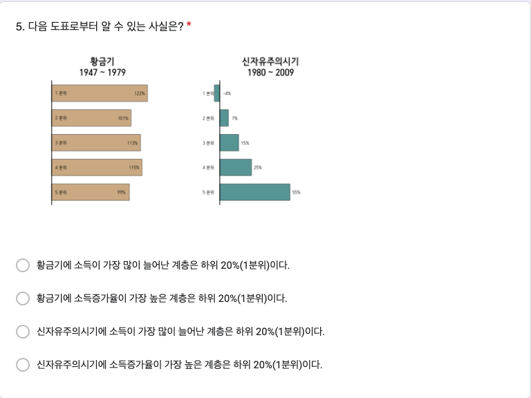

### 5분위별 소득증가율 비교

|  | 황금기에 소득이 가장 많이 늘어난 계층은 하위 20%(1분위)이다. | 황금기에 소득증가율이 가장 높은 계층은 하위 20%(1분위)이다. | 신자유주의시기에 소득이 가장 많이 늘어난 계층은 하위 20%(1분위)이다. | 신자유주의시기에 소득증가율이 가장 높은 계층은 하위 20%(1분위)이다. | 계 |
| --- | --- | --- | --- | --- | --- |
| **Red** | 41 | 182 | 40 | 18 | 281 |
| **Black** | 48 | 170 | 31 | 31 | 280 |
| **계** | 89 | 352 | 71 | 49 | 561 |

Pearson’s Chi-squared test: `.`

| Test statistic | df | P value |
| --- | --- | --- |
| 5.548 | 3 | 0.1358 |

Q5의 집계 결과가 Red, Black 간에 통계적으로 유의한 차이가 있는지 알아보기 위하여 카이제곱 테스트를 수행하였습니다.

그 결과 카이제곱 통계량은 5.548, 자유도는 3, p-value 는 0.1358이므로 Red, Black 간에 통계적으로 유의한 차이를 보이지 않습니다.

실제로 닮은 게 느껴집니까?

### 5분위별 소득증가율 비교 (%)

| 황금기에 소득이 가장 많이 늘어난 계층은 하위 20%(1분위)이다. | 황금기에 소득증가율이 가장 높은 계층은 하위 20%(1분위)이다. | 신자유주의시기에 소득이 가장 많이 늘어난 계층은 하위 20%(1분위)이다. | 신자유주의시기에 소득증가율이 가장 높은 계층은 하위 20%(1분위)이다. | 계 |
| --- | --- | --- | --- | --- |
| 15.9 | 62.7 | 12.7 | 8.7 | 100.0 |

정답률은 Red, Black 을 합하여 계산하는데, 62.7(%) 입니다.

## Q6. 주역

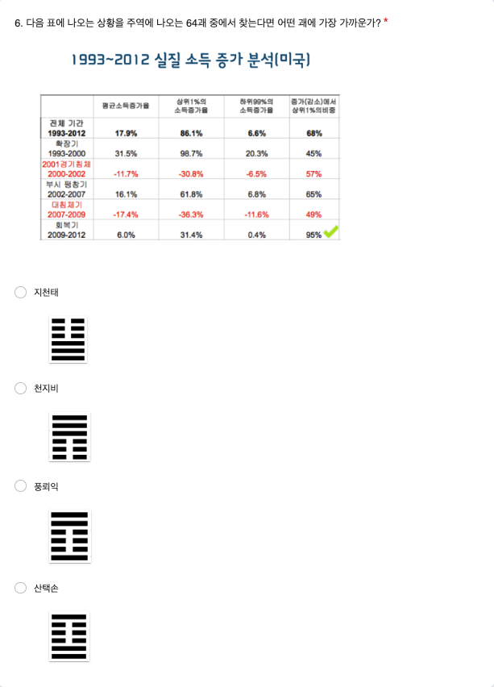

### 천지비

|  | 지천태 | 천지비 | 풍뢰익 | 산택손 | 계 |
| --- | --- | --- | --- | --- | --- |
| **Red** | 41 | 170 | 39 | 31 | 281 |
| **Black** | 38 | 163 | 46 | 33 | 280 |
| **계** | 79 | 333 | 85 | 64 | 561 |

Pearson’s Chi-squared test: `.`

| Test statistic | df | P value |
| --- | --- | --- |
| 0.8983 | 3 | 0.8258 |

Q6의 집계 결과가 Red, Black 간에 통계적으로 유의한 차이가 있는지 알아보기 위하여 카이제곱 테스트를 수행하였습니다.

그 결과 카이제곱 통계량은 0.898, 자유도는 3, p-value 는 0.8258이므로 Red, Black 간에 통계적으로 유의한 차이를 보이지 않습니다.

실제로 닮은 게 느껴집니까?

### 천지비 (%)

| 지천태 | 천지비 | 풍뢰익 | 산택손 | 계 |
| --- | --- | --- | --- | --- |
| 14.1 | 59.4 | 15.2 | 11.4 | 100.0 |

정답률은 Red, Black 을 합하여 계산하는데, 59.4(%) 입니다.

## Q7. Prospect Theory : 이득과 손실

이득은 확고히 하고, 손실은 피하고자 하는 보통 사람들의 심리적 경향을 확인합니다.

기대값을 계산해 보면 어느 게임을 선택하더라도 상관이 없어야 하는 데 이득 게임인 Red에서는 조금 덜 받더라도이득을 확고히 하려는 게임(A)에, 손실 게임인 Black에서는 손실을 확률적으로 줄이려는 게임(B)을 많이 선택하여 Kahneman과 Tversky의 Prospect Theory 에 부합하는 결과를 보여줍니다.

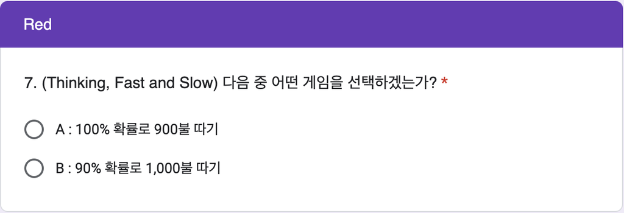

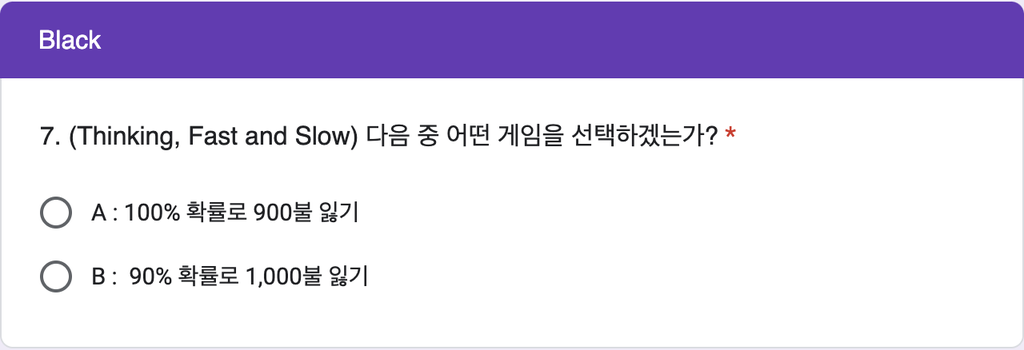

### 집계

|  | 확률 100% | 확률 90% | 계 |
| --- | --- | --- | --- |
| **이득 게임** | 205 | 76 | 281 |
| **손실 게임** | 84 | 196 | 280 |
| **계** | 289 | 272 | 561 |

Pearson’s Chi-squared test with Yates’ continuity correction: `.`

| Test statistic | df | P value |
| --- | --- | --- |
| 101.9 | 1 | 5.875e-24 * * * |

Q7의 Red 는 100%의 확률로 900달러를 따거나 90%의 확률로 1000달러를 따는 게임 중에서 많은 사람들이 900달러를 확고하게 갖는 것이 혹시라도 모를 10%의 확률로 아무 것도 안 생기는 것보다 선호한다는 것을 보여줍니다.

Black 은 100%의 확률로 900달러를 잃거나 90%의 확률로 1000달러를 잃는 게임 중에서는 손실을 확고히 하기 보다 10%의 확률이라도 1000달러의 손실을 회피하는 게임을 선호한다는 것을 보여줍니다.

이론적으로는 손실 게임이나 이득 게임이나 기대값이 같기 때문에 100% 게임이나 90% 게임을 비슷하게 선택할 것으로 생각되지만 우리의 실제 행동은 전혀 그렇지 않다는 것을 보여 줍니다.

여기서 수행하고 있는 카이제곱 테스트는 이득은 확고히 하고 손실은 운에 기대어 회피하려는 경향을 잘 보여 줍니다.

그 결과 카이제곱 통계량은 101.89, 자유도는 1, p-value 는 5.9e-24 합리적 행동을 한다는 가설로부터 어떤 선택도 비슷하게 나오리라는 기대와는 통계적으로 매우, 매우 유의하게 차이나는 결과를 보여줍니다.

### % 비교

|  | 확률 100% | 확률 90% | 계 |
| --- | --- | --- | --- |
| **이득 게임** | 73.0 | 27.0 | 100.0 |
| **손실 게임** | 30.0 | 70.0 | 100.0 |

이를 백분율로 살펴보면 이득 게임인 Red에서 100% 확률로 900달러를 따려는 사람들의 백분율, 73.0(%)은 90% 확률로 1000달러를 따려는 사람들의 백분율, 27.0(%) 보다 월등히 높습니다.반면 손실 게임인 Black에서 100% 확률로 900달러를 잃겠다는 사람들의 백분율, 30.0(%)은 90%의 확률로 1000달러를 잃겠다는 사람들의 백분율, 70.0(%) 보다 적습니다.

### Mosaic Plot

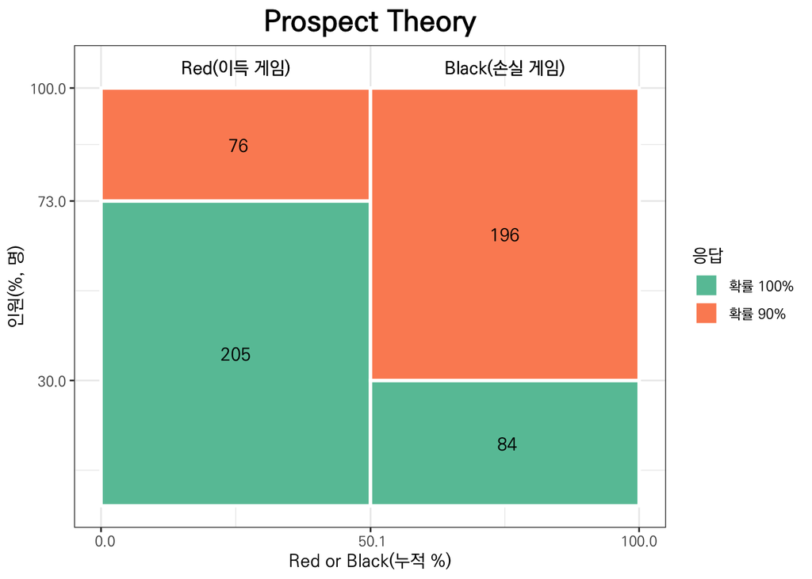

Mosaic Plot 은 이 집계결과를 시각적으로 잘 보여줍니다.

## 마감 시간으로부터 제출 시간의 분포

### 분포표

일 단위

|  | [0,1] | (1,2] | (2,3] | (3,4] | (4,5] | (5,6] | (6,7] | (7,8] | (8,9] | (9,10] | (10,11] | (11,12] | (12,13] | (13,14] | 계 |
| --- | --- | --- | --- | --- | --- | --- | --- | --- | --- | --- | --- | --- | --- | --- | --- |
| **Red** | 118 | 23 | 11 | 6 | 1 | 7 | 8 | 23 | 18 | 14 | 16 | 14 | 8 | 14 | 281 |
| **Black** | 136 | 20 | 13 | 5 | 3 | 5 | 6 | 26 | 11 | 10 | 10 | 15 | 9 | 11 | 280 |
| **계** | 254 | 43 | 24 | 11 | 4 | 12 | 14 | 49 | 29 | 24 | 26 | 29 | 17 | 25 | 561 |

분포표로부터 두 가지 문제를 살펴보겠습니다.

첫째, 날마다 고르게 제출하는가?

둘째, Red, Black 간에 통계적으로 유의한 차이가 있는가?

각 문제를 살펴보기 위해서는 분포표의 일부분을 대상으로 카이제곱 테스트를 수행합니다.

### 날마다 고르게 제출하는가?

| [0,1] | (1,2] | (2,3] | (3,4] | (4,5] | (5,6] | (6,7] | (7,8] | (8,9] | (9,10] | (10,11] | (11,12] | (12,13] | (13,14] |
| --- | --- | --- | --- | --- | --- | --- | --- | --- | --- | --- | --- | --- | --- |
| 254 | 43 | 24 | 11 | 4 | 12 | 14 | 49 | 29 | 24 | 26 | 29 | 17 | 25 |

Chi-squared test for given probabilities: `.`

| Test statistic | df | P value |
| --- | --- | --- |
| 1277 | 13 | 3.904e-265 * * * |

날마다 고르게 제출하는지 알아 보았습니다.

분포표의 “계”행에서 ’계’열을 제외하고 카이제곱테스트를 수행합니다.

분포표 만으로도 쉽게 파악할 수 있지만 카이제곱테스트가 명확히 해 줍니다.

카이제곱 통계량은 1277.392, 자유도는 13.00, p-value 는 3.9e-265 이므로 날짜별로 고르게 제출하지 않고 있음을 강력히 시사합니다.

막대그래프로 살펴 보겠습니다.

### 막대그래프

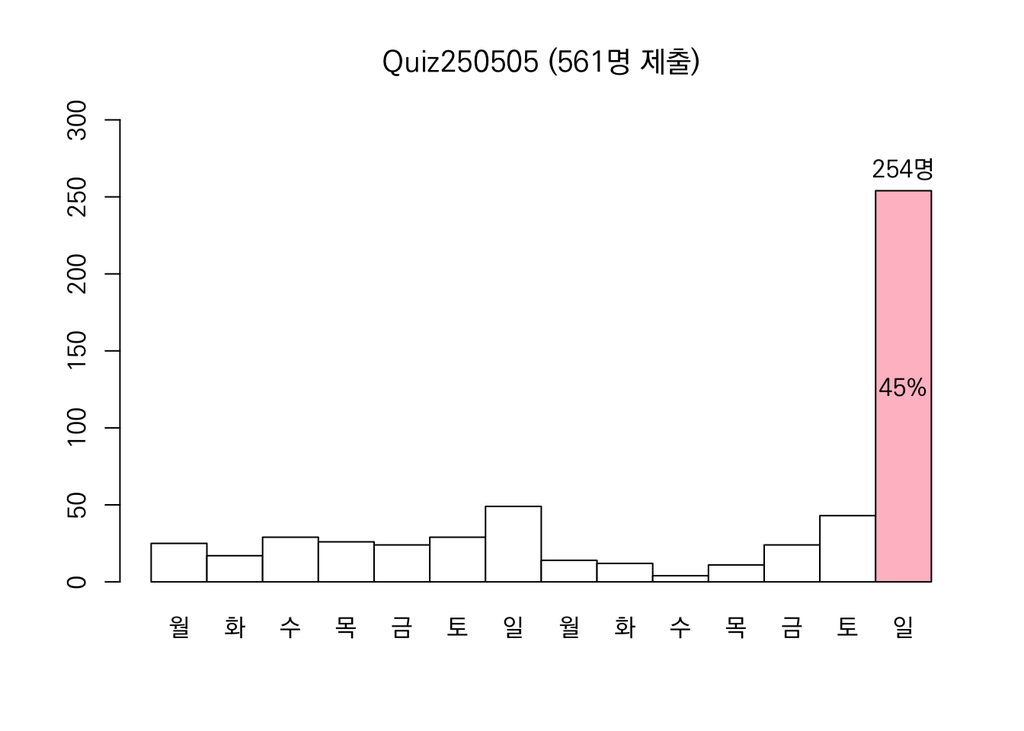

### Red, Black 간에 닮았는가?

|  | [0,1] | (1,2] | (2,3] | (3,4] | (4,5] | (5,6] | (6,7] | (7,8] | (8,9] | (9,10] | (10,11] | (11,12] | (12,13] | (13,14] |
| --- | --- | --- | --- | --- | --- | --- | --- | --- | --- | --- | --- | --- | --- | --- |
| **Red** | 118 | 23 | 11 | 6 | 1 | 7 | 8 | 23 | 18 | 14 | 16 | 14 | 8 | 14 |
| **Black** | 136 | 20 | 13 | 5 | 3 | 5 | 6 | 26 | 11 | 10 | 10 | 15 | 9 | 11 |

Pearson’s Chi-squared test: `.`

| Test statistic | df | P value |
| --- | --- | --- |
| 7.738 | 13 | 0.8603 |

제출시간의 분포가 Red, Black 간에 닮았는지 알아 보았습니다.

이번에는 분포표의 첫번째와 두번째 행, ’계’열을 제외한 나머지 열에 대해서 카이제곱테스트를 수행합니다.

카이제곱 통계량은 7.74, 자유도는 13, p-value 는 0.8603 이므로 제출 시간의 분포는 Red, Black 간에 통계적으로 유의한 차이가 관찰되지 않습니다.

이 사실을 Mosaic Plot 을 이용하여 시각적으로 살펴보겠습니다.

닮았다고 느껴지나요?

### Mosaic Plot

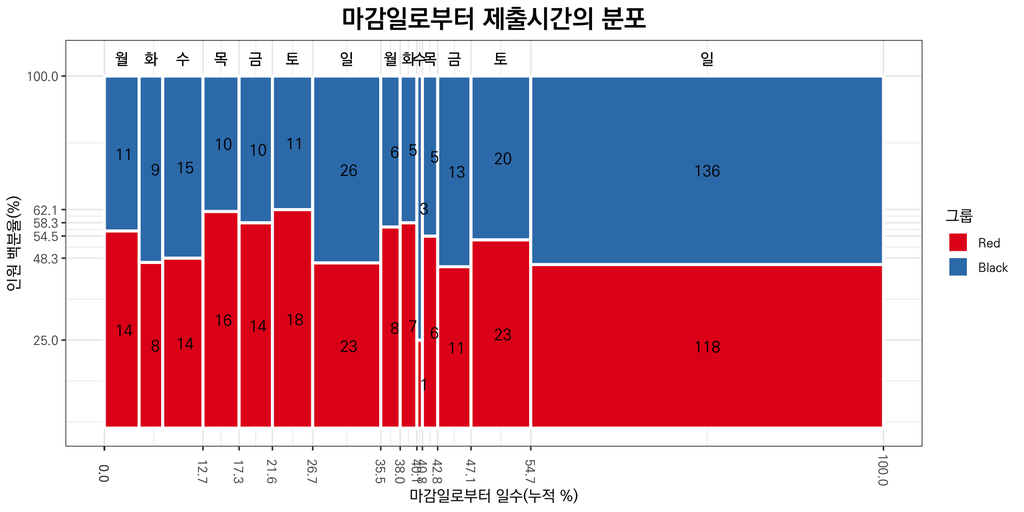